# KKR_RCB

[figure not shown]

```python
!pip install ipywidgets
!pip install ipympl
!jupyter labextension install @jupyter-widgets/jupyterlab-manager
!jupyter nbextension install --user --py widgetsnbextension
!jupyter nbextension enable --user --py widgetsnbextension
!pip install plotly
!pip install cufflinks
```

[output not shown]

[output not shown]

```python
import operator
import pandas as pd
import numpy as np
import matplotlib.pyplot as plt
import seaborn as sns
%matplotlib inline
import warnings
warnings.filterwarnings("ignore")
import ipywidgets as widgets
import plotly.express as px
import plotly.graph_objects as go

from __future__ import print_function
from ipywidgets import interact, interactive, fixed, interact_manual
pd.set_option('display.max_columns', 50)
%matplotlib widget
```

```python
matches = pd.read_csv("matches.csv")
deliveries =  pd.read_csv("deliveries.csv")
IPL_data = pd.merge(deliveries, matches[['id','season', 'team1', 'team2', 'toss_winner', 'toss_decision','winner','result', 'dl_applied','win_by_runs','win_by_wickets', 'venue' ]],
                    left_on='match_id', right_on='id')
```

```python
RCB_batsmen = ['AJ Finch', 'V Kohli', 'AB de Villiers', 'Washington Sundar','Gurkeerat Singh', 'S Dube', 'CH Morris']
#D Paddikal: new player, S Dube/ Gurkeerat (optional)

RCB_bowlers = ['CH Morris', 'YS Chahal', 'N Saini', 'Washington Sundar','Mohammed Siraj']
# I Udana new player: Bowler ER:9.72

#KKR batsmen
KKR_batsmen = ['S Gill', 'RA Tripathi', 'N Rana', 'KD Karthik', 'EJG Morgan', 'AD Russell', 'PJ Cummins']
# SP Narine/AD Russell(optional)

#KKR bowlers
KKR_bowlers = ['PJ Cummins',  'S Mavi', 'LH Ferguson','Kuldeep Yadav', 'AD Russell', 'V Chakravarthy', 'SP Narine']
# LH ferguson instead of P Krishna
#nagarkoti not found
```

# Question 2: How many wickets will RCB loose in between 31st and 120th ball?

## 2.1 : RCB batmen dismissal in 31st to 120th ball overal in IPL

```python
RCB_ = deliveries[deliveries.batsman.isin(RCB_batsmen) & (deliveries.over >= 6)]
RCB_.player_dismissed.fillna(0, inplace = True)
# matchwise details
RCB_M = RCB_[["match_id", "batsman","player_dismissed"]]

batsman = []
matches_played = []
for i in RCB_M.batsman.unique():
    batsman.append(i)
    matches_played.append(len(RCB_M[RCB_M.batsman == i].match_id.unique()))


RCB_M_W = RCB_M[RCB_M.player_dismissed != 0].groupby(["batsman"])["player_dismissed"].count().reset_index()

# interactive scatter plot
def create_scatter(feature1, feature2):
    with plt.style.context("ggplot"):
        fig = plt.figure(figsize=(12,4))

        plt.scatter(x = RCB_M_W[feature1],
                    y = RCB_M_W[feature2],
                    c=RCB_M_W.index,
                    s=300
                   )

        plt.xlabel(feature1.capitalize())
        plt.ylabel(feature2.capitalize())

        plt.title("%s vs %s"%(feature1.capitalize(), feature2.capitalize()))
        plt.show()

feature1_drop = widgets.Dropdown(options=RCB_M_W.columns, value = RCB_M_W.columns[0])
feature2_drop = widgets.Dropdown(options=RCB_M_W.columns, value = RCB_M_W.columns[1])
out = widgets.interactive_output(create_scatter, {'feature1': feature1_drop, 'feature2':feature2_drop})

type(out)

widgets.VBox([widgets.HBox([feature1_drop, feature2_drop]), out])
```

```python
RCB_M_W
```

|  | batsman | player_dismissed |
| --- | --- | --- |
| 0 | AB de Villiers | 86 |
| 1 | AJ Finch | 40 |
| 2 | CH Morris | 20 |
| 3 | Gurkeerat Singh | 25 |
| 4 | S Dube | 4 |
| 5 | V Kohli | 117 |
| 6 | Washington Sundar | 6 |

#### select batsman / matchid in 1st box and select player dismissed in second box it will give a count of dismissal for each player,

## 2.2 Dismissal percentage of RCB batsmen in overs 5-20

```python
RCB_M_W_ = RCB_M_W.groupby(["batsman"])["player_dismissed"].sum().reset_index()
# According to above numbera
m_play = [124,48,37,26,4,135,12]
RCB_M_W_["no_of_matches_played"] = m_play
RCB_M_W_["dismissal_percentage"] = (RCB_M_W_.player_dismissed/RCB_M_W_.no_of_matches_played)*100
import numpy as np

import cufflinks as cf

print("List of Cufflinks Themes : ", cf.getThemes())

cf.set_config_file(theme='pearl',sharing='public',offline=True)
RCB_M_W_.iplot(kind="bar",x = "batsman",
                  subplots=True,
                  sortbars=True,
                  keys = ["no_of_matches_played","player_dismissed", "dismissal_percentage"],
                  title="Dismissal percentage of RCB batsmen in balls 31-120",
                  theme="henanigans"
                  )
RCB_M_W_
```

```
List of Cufflinks Themes :  ['ggplot', 'pearl', 'solar', 'space', 'white', 'polar', 'henanigans']
```

[interactive chart not shown]

|  | batsman | player_dismissed | no_of_matches_played | dismissal_percentage |
| --- | --- | --- | --- | --- |
| 0 | AB de Villiers | 86 | 124 | 69.354839 |
| 1 | AJ Finch | 40 | 48 | 83.333333 |
| 2 | CH Morris | 20 | 37 | 54.054054 |
| 3 | Gurkeerat Singh | 25 | 26 | 96.153846 |
| 4 | S Dube | 4 | 4 | 100.000000 |
| 5 | V Kohli | 117 | 135 | 86.666667 |
| 6 | Washington Sundar | 6 | 12 | 50.000000 |

S dube/Gurkeerat (optional)

## 2.3 dismissal percentage of batsmen in 1st 5 overs

V Kohli, AB de villiars, AJ Finch

```python
first_five_over = ["AJ Finch", "AB de Villiers", "V Kohli"]
RCB_1 = deliveries[deliveries.batsman.isin(RCB_batsmen) & (deliveries.over < 6)]
RCB_1.player_dismissed.fillna(0, inplace = True)
# matchwise details
RCB_M1 = RCB_1[["match_id", "batsman","player_dismissed"]]

batsman1 = []
matches_played1 = []
for i in RCB_M1.batsman.unique():
    batsman1.append(i)
    matches_played1.append(len(RCB_M1[RCB_M1.batsman == i].match_id.unique()))

RCB_M_W1 = RCB_M1[RCB_M1.player_dismissed != 0].groupby(["match_id", "batsman"])["player_dismissed"].count().reset_index()


RCB_M_W_1 = RCB_M_W1.groupby(["batsman"])["player_dismissed"].sum().reset_index()
# According to above numbers
m_play1 = [61,49,5,117]
RCB_M_W_1["no_of_matches_played"] = m_play1
RCB_M_W_1["dismissal_percentage"] = (RCB_M_W_1.player_dismissed/RCB_M_W_1.no_of_matches_played)*100
import numpy as np

import cufflinks as cf

print("List of Cufflinks Themes : ", cf.getThemes())

cf.set_config_file(theme='pearl',sharing='public',offline=True)
RCB_M_W_1.iplot(kind="bar",x = "batsman",
                  subplots=True,
                  sortbars=True,
                  keys = ["no_of_matches_played","player_dismissed", "dismissal_percentage"],
                  title="Dismissal percentage of RCB batsmen in balls 31-120",
                  theme="henanigans"
                  )
RCB_M_W_1
```

```
List of Cufflinks Themes :  ['ggplot', 'pearl', 'solar', 'space', 'white', 'polar', 'henanigans']
```

[interactive chart not shown]

|  | batsman | player_dismissed | no_of_matches_played | dismissal_percentage |
| --- | --- | --- | --- | --- |
| 0 | AB de Villiers | 18 | 61 | 29.508197 |
| 1 | AJ Finch | 26 | 49 | 53.061224 |
| 2 | Gurkeerat Singh | 1 | 5 | 20.000000 |
| 3 | V Kohli | 35 | 117 | 29.914530 |

### Assumption : Dismissal percentage should be >60

## AJ Fince = 1 S dube/Gurkeerat Singh = 1 AB de villiars =1 V Kohli =1

## 2.4 Dismissal of RCB batsmen against KKR bowlers (overs 6-20)

```python
RCB_KKR = deliveries[deliveries.batsman.isin(RCB_batsmen) & (deliveries.over >= 6) & (deliveries.bowler.isin(KKR_bowlers))]
RCB_KKR.player_dismissed.fillna(0, inplace = True)
# matchwise details
RCB_KKR_M = RCB_KKR[["match_id", "batsman","bowler","player_dismissed"]]

t_RCB_KKR= RCB_KKR_M[RCB_KKR_M.player_dismissed == 0].groupby(["match_id", "batsman", "bowler"])["player_dismissed"].sum().reset_index()
#t_RCB_KKR["dismissal_status"] = "not_out"
RCB_KKR_M_W = RCB_KKR_M[RCB_KKR_M.player_dismissed != 0].groupby(["match_id", "batsman", "bowler"])["player_dismissed"].count().reset_index()

f = [t_RCB_KKR,RCB_KKR_M_W ]
RCB_KKR_wickets = pd.concat(f)
RCB_KKR_wickets["details"] = "dismissal"
fig = px.sunburst(RCB_KKR_wickets,
                  path=["details","batsman", "bowler", "player_dismissed"],
                  width=750, height=750,
                  color_continuous_scale="twilight",
                  color='player_dismissed',
                  title="Dismissal of RCB batsmen against KKR bowlers matchwise",
                  )
fig.show()
```

[interactive chart not shown]

## 2.5 Dismissal of RCB batsmen against KKR bowlers in overs 1-5

```python
RCB_KKR1 = deliveries[deliveries.batsman.isin(RCB_batsmen) & (deliveries.over <6) & (deliveries.bowler.isin(KKR_bowlers))]
RCB_KKR1.player_dismissed.fillna(0, inplace = True)
# matchwise details
RCB_KKR_M1 = RCB_KKR1[["match_id", "batsman","bowler","player_dismissed"]]

t_RCB_KKR1= RCB_KKR_M1[RCB_KKR_M1.player_dismissed == 0].groupby(["match_id", "batsman", "bowler"])["player_dismissed"].sum().reset_index()
#t_RCB_KKR["dismissal_status"] = "not_out"
RCB_KKR_M_W1 = RCB_KKR_M1[RCB_KKR_M1.player_dismissed != 0].groupby(["match_id", "batsman", "bowler"])["player_dismissed"].count().reset_index()

f1 = [t_RCB_KKR1,RCB_KKR_M_W1 ]
RCB_KKR_wickets1 = pd.concat(f1)
RCB_KKR_wickets1["details"] = "dismissal"
fig = px.sunburst(RCB_KKR_wickets1,
                  path=["details","batsman", "bowler", "player_dismissed"],
                  width=750, height=750,
                  color_continuous_scale="twilight",
                  color='player_dismissed',
                  title="Dismissal of RCB batsmen against KKR bowlers matchwise in overs 1-5",
                  )
fig.show()
```

[interactive chart not shown]

0 =no dismissal (by the bowler), 1 = out

```python
RCB_KKR3 = deliveries[(deliveries.over >= 6) & (deliveries.bowler.isin(KKR_bowlers))]
RCB_KKR3.player_dismissed.fillna(0, inplace = True)
# matchwise details
RCB_KKR_M3 = RCB_KKR3[["match_id", "batsman","bowler","player_dismissed"]]

t_RCB_KKR3 = RCB_KKR_M3[RCB_KKR_M3.player_dismissed == 0].groupby(["match_id", "batsman", "bowler"])["player_dismissed"].sum().reset_index()
#t_RCB_KKR["dismissal_status"] = "not_out"
RCB_KKR_M_W3 = RCB_KKR_M3[RCB_KKR_M3.player_dismissed != 0].groupby(["match_id", "batsman", "bowler"])["player_dismissed"].count().reset_index()

f3 = [t_RCB_KKR3,RCB_KKR_M_W3 ]
RCB_KKR_wickets3 = pd.concat(f3)
RCB_KKR_wickets3["details"] = "dismissal"


bowler = []
match_bowler = []
for i in RCB_KKR_M3.bowler.unique():
    x = RCB_KKR_M3[RCB_KKR_M3.bowler == i]
    bowler.append(i)
    match_bowler.append(len(x.match_id.unique()))

print(bowler,match_bowler)

RCB_KKR_M_W3_ = RCB_KKR_M_W3.groupby(["bowler"])["player_dismissed"].sum().reset_index()

RCB_KKR_M_W3_["no_of_matches"] = [55, 39,4, 15, 8, 109, 1]
RCB_KKR_M_W3_
RCB_KKR_M_W3_["percentage_of_wickets"] = (RCB_KKR_M_W3_.player_dismissed/RCB_KKR_M_W3_.no_of_matches)*100
RCB_KKR_M_W3_
```

```
['Kuldeep Yadav', 'SP Narine', 'PJ Cummins', 'LH Ferguson', 'AD Russell', 'S Mavi', 'V Chakravarthy'] [39, 109, 15, 4, 55, 8, 1]
```

|  | bowler | player_dismissed | no_of_matches | percentage_of_wickets |
| --- | --- | --- | --- | --- |
| 0 | AD Russell | 48 | 55 | 87.272727 |
| 1 | Kuldeep Yadav | 42 | 39 | 107.692308 |
| 2 | LH Ferguson | 4 | 4 | 100.000000 |
| 3 | PJ Cummins | 15 | 15 | 100.000000 |
| 4 | S Mavi | 6 | 8 | 75.000000 |
| 5 | SP Narine | 120 | 109 | 110.091743 |
| 6 | V Chakravarthy | 1 | 1 | 100.000000 |

# Question 3: How many balls will AB de villiers take to score 30 runs

## 3.1 : AB de Villiers score of less/greater than 30

```python
ABD = deliveries[deliveries.batsman == "AB de Villiers"]
match_count_abd = len(ABD.match_id.unique())
ABD_r = ABD.groupby(['match_id'])['batsman_runs'].count().reset_index(name = "ball_faced")
temp_abd = ABD.groupby(['match_id'])['batsman_runs'].sum().reset_index()
ABD_r["runs_scored"] = temp_abd.batsman_runs
ABD_rG = ABD_r[ABD_r.runs_scored >=30]
ABD_rL = ABD_r[ABD_r.runs_scored <30]

print("number of times AB de Villiers scored less than 30 : " ,ABD_rL.shape[0], " | ", ((ABD_rL.shape[0]/match_count_abd)*100), "%" )
print("#########################################################################################################################")
print("number of times AB de Villiers scored greater than 30 : ", ABD_rG.shape[0]," | ", ((ABD_rG.shape[0]/match_count_abd)*100), "%")
```

```
number of times AB de Villiers scored less than 30 :  86  |  60.56338028169014 %
#########################################################################################################################
number of times AB de Villiers scored greater than 30 :  56  |  39.436619718309856 %
```

## 3.2 : Balls taken to score >=30 runs by AB de Villiers

```python
# average number of balls faced to score >=30
print("average number of balls faced to score >30 runs by AB de Villiers are:",ABD_rG.ball_faced.mean())
```

```
average number of balls faced to score >30 runs by AB de Villiers are: 35.589285714285715
```

#### as all the matches with runs scored >=30 are considered, here, the runs could be 80, 100 or more. Hence, we need to limit our range to 30-35,30-40, 30-50 and find the centrality.

```python
print("balls required to score 30-35 runs")
print("---------------------------------------------------------")
print("mean value:",ABD_rG[ABD_rG.runs_scored <=35].ball_faced.mean())
print("median value:",ABD_rG[ABD_rG.runs_scored <=35].ball_faced.median())
print("frequent value:",ABD_rG[ABD_rG.runs_scored <=35].ball_faced.mode())
print("---------------------------------------------------------")
print("balls required to score 30-40 runs")
print("---------------------------------------------------------")
print("mean value:",ABD_rG[ABD_rG.runs_scored <=40].ball_faced.mean())
print("median value:",ABD_rG[ABD_rG.runs_scored <=40].ball_faced.median())
print("frequent value:",ABD_rG[ABD_rG.runs_scored <=40].ball_faced.mode())
print("--------------------------------------------------------")
print("balls required to score 30-50 runs")
print("--------------------------------------------------------")
print("mean value:",ABD_rG[ABD_rG.runs_scored <=50].ball_faced.mean())
print("median value:",ABD_rG[ABD_rG.runs_scored <=50].ball_faced.median())
print("frequent value:",ABD_rG[ABD_rG.runs_scored <=50].ball_faced.mode())
```

```
balls required to score 30-35 runs
---------------------------------------------------------
mean value: 16.8
median value: 17.0
frequent value: 0    17
dtype: int64
---------------------------------------------------------
balls required to score 30-40 runs
---------------------------------------------------------
mean value: 21.75
median value: 18.5
frequent value: 0    17
dtype: int64
--------------------------------------------------------
balls required to score 30-50 runs
--------------------------------------------------------
mean value: 27.045454545454547
median value: 27.5
frequent value: 0    17
dtype: int64
```

## 3.3 : Analysis Against KKR bowlers

```python
ABD_ = deliveries[(deliveries.batsman == "AB de Villiers") & (deliveries.bowler.isin(KKR_bowlers))]
match_count_abd_ = len(ABD_.match_id.unique())
ABD_r_ = ABD_.groupby(['match_id'])['batsman_runs'].count().reset_index(name = "ball_faced")
temp_abd_ = ABD_.groupby(['match_id'])['batsman_runs'].sum().reset_index()
ABD_r_["runs_scored"] = temp_abd_.batsman_runs
ABD_rG_ = ABD_r_[ABD_r_.runs_scored >=30]
ABD_rL_ = ABD_r_[ABD_r_.runs_scored <30]

print("number of times AB de Villiers scored less than 30 : " ,ABD_rL_.shape[0], " | ", ((ABD_rL_.shape[0]/match_count_abd_)*100), "%" )
print("#########################################################################################################################")
print("number of times AB de Villiers scored greater than 30 : ", ABD_rG_.shape[0]," | ", ((ABD_rG_.shape[0]/match_count_abd_)*100), "%")
```

```
number of times AB de Villiers scored less than 30 :  10  |  90.9090909090909 %
#########################################################################################################################
number of times AB de Villiers scored greater than 30 :  1  |  9.090909090909092 %
```

```python
ABD_.groupby(['match_id', "bowler"])['batsman_runs'].count().reset_index(name = "ball_faced")
```

|  | match_id | bowler | ball_faced |
| --- | --- | --- | --- |
| 0 | 33 | LH Ferguson | 3 |
| 1 | 45 | SP Narine | 3 |
| 2 | 392 | SP Narine | 8 |
| 3 | 441 | SP Narine | 1 |
| 4 | 468 | SP Narine | 1 |
| 5 | 506 | SP Narine | 4 |
| 6 | 522 | AD Russell | 4 |
| 7 | 606 | SP Narine | 1 |
| 8 | 624 | SP Narine | 4 |
| 9 | 7896 | AD Russell | 4 |
| 10 | 7896 | Kuldeep Yadav | 4 |
| 11 | 7896 | SP Narine | 5 |
| 12 | 11153 | AD Russell | 4 |
| 13 | 11153 | Kuldeep Yadav | 8 |
| 14 | 11153 | SP Narine | 8 |

### He hasn't face many bowlers from KKR in the past

```python
print("average number of balls faced by AB de Villiers are:", ABD_r.ball_faced.mean())
```

```
average number of balls faced by AB de Villiers are: 20.964788732394368
```

```python
KKR_b = deliveries[(deliveries.bowler.isin(KKR_bowlers))]
matc_c = len(KKR_b.match_id.unique())

KKR_b_ = KKR_b.groupby(['match_id', 'bowler'])['batsman_runs'].count().reset_index(name = "ball_faced")
temp_kkr = KKR_b.groupby(['match_id', 'bowler'])['batsman_runs'].sum().reset_index()
KKR_b_["runs_scored"] = temp_kkr.batsman_runs
KKR_b_rG_ = KKR_b_[KKR_b_.runs_scored >=30]
KKR_b_rL_ = KKR_b_[KKR_b_.runs_scored <30]


# let us consider on 30-32
for i in KKR_b_rG_[KKR_b_rG_.runs_scored <33].bowler.unique():
    x1 = KKR_b_rG_[KKR_b_rG_.runs_scored <33][KKR_b_rG_.bowler == i]
    print(x1)
    print("###############################################################################")
    print("Average balls faced by batsman against ", i, " are : ", x1.ball_faced.mean())
    print("###############################################################################")
```

```
     match_id         bowler  ball_faced  runs_scored
18         29  Kuldeep Yadav          24           31
125       581  Kuldeep Yadav          25           32
160      7906  Kuldeep Yadav          20           32
209     11142  Kuldeep Yadav          26           32
215     11153  Kuldeep Yadav          24           31
###############################################################################
Average balls faced by batsman against  Kuldeep Yadav  are :  23.8
###############################################################################
    match_id      bowler  ball_faced  runs_scored
28        41  PJ Cummins          24           30
34        51  PJ Cummins          25           30
###############################################################################
Average balls faced by batsman against  PJ Cummins  are :  24.5
###############################################################################
     match_id      bowler  ball_faced  runs_scored
59        380  AD Russell          24           30
63        385  AD Russell          19           30
122       570  AD Russell          24           32
142       624  AD Russell          15           32
166      7911  AD Russell          11           31
174      7922  AD Russell          20           31
205     11138  AD Russell          18           32
231     11334  AD Russell          18           32
235     11343  AD Russell          19           30
###############################################################################
Average balls faced by batsman against  AD Russell  are :  18.666666666666668
###############################################################################
     match_id     bowler  ball_faced  runs_scored
66        397  SP Narine          24           31
67        400  SP Narine          25           32
90        491  SP Narine          24           30
97        514  SP Narine          24           30
131       596  SP Narine          24           32
151      7896  SP Narine          24           31
216     11153  SP Narine          25           30
228     11326  SP Narine          25           32
###############################################################################
Average balls faced by batsman against  SP Narine  are :  24.375
###############################################################################
```

```python
for i in KKR_b_rG_.bowler.unique():
    y = KKR_b_rG_[KKR_b_rG_.bowler == i]
    print("Number of times batsman scored more than 30 against", i, y.shape[0])
print("###################################################################################################")
for i in KKR_b_rL_.bowler.unique():
    y1 = KKR_b_rL_[KKR_b_rL_.bowler == i]
    print("Number of times batsman scored less than 30 against", i, y1.shape[0])
```

```
Number of times batsman scored more than 30 against SP Narine 33
Number of times batsman scored more than 30 against Kuldeep Yadav 18
Number of times batsman scored more than 30 against LH Ferguson 1
Number of times batsman scored more than 30 against PJ Cummins 7
Number of times batsman scored more than 30 against AD Russell 21
Number of times batsman scored more than 30 against S Mavi 4
Number of times batsman scored more than 30 against V Chakravarthy 1
###################################################################################################
Number of times batsman scored less than 30 against Kuldeep Yadav 21
Number of times batsman scored less than 30 against PJ Cummins 9
Number of times batsman scored less than 30 against SP Narine 76
Number of times batsman scored less than 30 against LH Ferguson 3
Number of times batsman scored less than 30 against AD Russell 40
Number of times batsman scored less than 30 against S Mavi 5
```

## There are higher chances of AB devilliers getting dismissed before scoring 30 runs but of he scores more than 30 then he will need balls in between 16-24

# Question 4: What will be the difference between strike rate of EJG Morgan (overall) and the strike rate of the last 7 balls he plays?

## 4.1 strike rate EJG Morgan overall

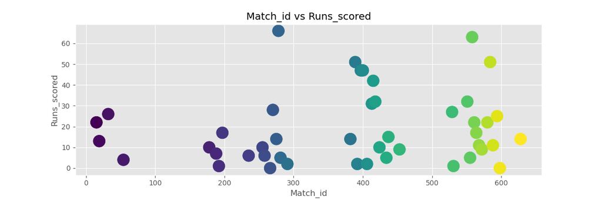

```python
EM = deliveries[deliveries.batsman  == "EJG Morgan"]
EM1 = EM.groupby(['match_id'])['batsman_runs'].count().reset_index(name = "ball_faced")
EM2 = EM.groupby(['match_id'])['batsman_runs'].sum().reset_index(name = "runs_scored")
EM1["runs_scored"] = EM2.runs_scored
# interactive scatter plot
def create_scatter(feature1, feature2):
    with plt.style.context("ggplot"):
        fig = plt.figure(figsize=(12,4))

        plt.scatter(x = EM1[feature1],
                    y = EM1[feature2],
                    c=EM1.index,
                    s=300
                   )

        plt.xlabel(feature1.capitalize())
        plt.ylabel(feature2.capitalize())

        plt.title("%s vs %s"%(feature1.capitalize(), feature2.capitalize()))
        plt.show()

feature1_drop = widgets.Dropdown(options=EM1.columns, value = EM1.columns[1])
feature2_drop = widgets.Dropdown(options=EM1.columns, value = EM1.columns[2])
out = widgets.interactive_output(create_scatter, {'feature1': feature1_drop, 'feature2':feature2_drop})

type(out)

widgets.VBox([widgets.HBox([feature1_drop, feature2_drop]), out])
```

[figure not shown]

```python
print("####################################################################################################################")
print("strike rate of Morgan in all matches is :", EM1.runs_scored.sum()*100/EM1.ball_faced.sum())
print("####################################################################################################################")
```

```
####################################################################################################################
strike rate of Morgan in all matches is : 117.79310344827586
####################################################################################################################
```

```python
# Strike rate of last 7 balls
EM1_L = EM1[EM1.ball_faced <=7]
EM1_G = EM1[EM1.ball_faced >7]
EM1_G_match = EM1_G.match_id.unique()
EM1_G_match_s = EM[EM.match_id.isin(EM1_G_match)]
EM1_G_match_sr = EM1_G_match_s[["match_id","batsman", "ball", "batsman_runs"]]
EM1_G_match_sr['ball'] =1

list_ = []
m = []
batsman_runs = []
ball_number = []
for i in EM1_G_match_sr.match_id.unique():
    t1 = EM1_G_match_sr[EM1_G_match_sr.match_id == i]
    t1["ball_number"] = t1.ball.cumsum()
    b1 = t1.ball_number.values[-7:]
    t2 = t1[t1.ball_number.isin(b1)]
    m.append(t2.match_id.values)
    ball_number.append(t2.ball_number.values)
    batsman_runs.append(t2.batsman_runs.values)


list_of_tuples = list(zip(m, ball_number, batsman_runs))
EJM_data = pd.DataFrame(list_of_tuples, columns = ['match_id', 'ball_nnmber', 'batsman_runs'])

total_runs = []
for i in EJM_data.index.values:
    total_runs.append(EJM_data.batsman_runs[i].sum())

EJM_data["runs_scored"] = total_runs
EJM_data["ball_faced"] = 7
EJM_data_ = EJM_data[["ball_faced", "runs_scored"]]
EM1_L_ = EM1_L[["ball_faced", "runs_scored"]]
k = [EM1_L_,EJM_data_]
EJMorgan_sr = pd.concat(k)
sr1 = EM1.runs_scored.sum()*100/EM1.ball_faced.sum()
sr2  = (EJMorgan_sr.runs_scored.median()*100)/EJMorgan_sr.ball_faced.median()
sr3 = (EJM_data_.runs_scored.mean()*100)/7
print("strike rate for last 7 balls faced by EJM Morgan overall in IPL is : ",(EJMorgan_sr.runs_scored.sum()*100)/EJMorgan_sr.ball_faced.sum())
```

```
strike rate for last 7 balls faced by EJM Morgan overall in IPL is :  119.23076923076923
```

```python
print("Hence difference in strike rates is (by considering matches where less than 7 balls faced) : ", sr1 - sr2)
print("Hence difference in strike rates is (by excluding matches where less than 7 balls faced) : ", sr3 - sr1)
```

```
Hence difference in strike rates is (by considering matches where less than 7 balls faced) :  17.793103448275858
Hence difference in strike rates is (by excluding matches where less than 7 balls faced) :  7.552518671539801
```

## 4.2 strike Rate against RCB bowlers

```python
EM_ = IPL_data[(IPL_data.batsman  == "EJG Morgan") & (IPL_data.bowling_team == "Royal Challengers Bangalore")]
EM1_ = EM_.groupby(['match_id'])['batsman_runs'].count().reset_index(name = "ball_faced")
EM2_ = EM_.groupby(['match_id'])['batsman_runs'].sum().reset_index(name = "runs_scored")
EM1_["runs_scored"] = EM2_.runs_scored
EM1_["strike_rate"] = EM1_.runs_scored *100/EM1_.ball_faced
print("Average strike rate against RCB bowlers", EM1_.runs_scored.mean()*100/EM1_.ball_faced.mean())
# interactive scatter plot
def create_scatter(feature1, feature2):
    with plt.style.context("ggplot"):
        fig = plt.figure(figsize=(12,4))

        plt.scatter(x = EM1_[feature1],
                    y = EM1_[feature2],
                    c=EM1_.index,
                    s=300
                   )

        plt.xlabel(feature1.capitalize())
        plt.ylabel(feature2.capitalize())

        plt.title("%s vs %s"%(feature1.capitalize(), feature2.capitalize()))
        plt.show()

feature1_drop = widgets.Dropdown(options=EM1_.columns, value = EM1_.columns[1])
feature2_drop = widgets.Dropdown(options=EM1_.columns, value = EM1_.columns[2])
out = widgets.interactive_output(create_scatter, {'feature1': feature1_drop, 'feature2':feature2_drop})

type(out)

widgets.VBox([widgets.HBox([feature1_drop, feature2_drop]), out])
```

```
Average strike rate against RCB bowlers 104.87804878048782
```

```python
EM1_
```

|  | match_id | ball_faced | runs_scored | strike_rate |
| --- | --- | --- | --- | --- |
| 0 | 258 | 6 | 6 | 100.000000 |
| 1 | 291 | 5 | 2 | 40.000000 |
| 2 | 392 | 5 | 2 | 40.000000 |
| 3 | 568 | 7 | 11 | 157.142857 |
| 4 | 580 | 18 | 22 | 122.222222 |

```python
s1 = EM1_[EM1_.ball_faced <=7]
s2 = EM1_[EM1_.ball_faced >7]
diff_sr = (s1.ball_faced.mean()*100/s1.runs_scored.mean()) - (s2.ball_faced.mean()*100/s2.runs_scored.mean())
print("difference in strike rate is: ", diff_sr)
```

```
difference in strike rate is:  27.705627705627705
```

## conclusion: Hence, the difference will be less than 75

# Question 5: how many runs will RCB score Off KKR in deaths

## 5.1 : RCB batsmen in death overs

```python
RCB_d  = deliveries[(deliveries.batsman.isin(RCB_batsmen)) & (deliveries.over >= 16)]
rcb_d = RCB_d.groupby(['match_id', 'batsman'])['batsman_runs'].sum().reset_index(name = "death_runs")
def create_scatter(feature1, feature2):
    with plt.style.context("ggplot"):
        fig = plt.figure(figsize=(12,4))

        plt.scatter(x = rcb_d[feature1],
                    y = rcb_d[feature2],
                    c=rcb_d.index,
                    s=300
                   )

        plt.xlabel(feature1.capitalize())
        plt.ylabel(feature2.capitalize())

        plt.title("%s vs %s"%(feature1.capitalize(), feature2.capitalize()))
        plt.show()

feature1_drop = widgets.Dropdown(options=rcb_d.columns, value = rcb_d.columns[1])
feature2_drop = widgets.Dropdown(options=rcb_d.columns, value = rcb_d.columns[2])
out = widgets.interactive_output(create_scatter, {'feature1': feature1_drop, 'feature2':feature2_drop})

type(out)

widgets.VBox([widgets.HBox([feature1_drop, feature2_drop]), out])
```

```python
for i in rcb_d.batsman.unique():
    z = rcb_d[rcb_d.batsman == i]
    print("Average runs scored by", i, " in deaths is: ", z.death_runs.mean())
```

```
Average runs scored by AB de Villiers  in deaths is:  22.41269841269841
Average runs scored by CH Morris  in deaths is:  13.758620689655173
Average runs scored by V Kohli  in deaths is:  17.484848484848484
Average runs scored by AJ Finch  in deaths is:  13.428571428571429
Average runs scored by Washington Sundar  in deaths is:  6.181818181818182
Average runs scored by Gurkeerat Singh  in deaths is:  13.25
Average runs scored by S Dube  in deaths is:  9.0
```

## 5.2 Economy rate wise

```python
dt_KKR = deliveries[(deliveries.bowler.isin(KKR_bowlers)) & (deliveries.over >=16) ]
dt1 = dt_KKR.groupby(['bowler'])['batsman_runs'].count().reset_index(name = "balls_bowled")
dt2 = dt_KKR.groupby(['bowler'])['batsman_runs'].sum().reset_index(name = "total_runs")
dt1["total_runs"] = dt2.total_runs
dt1["economy_rate"] = (dt1.total_runs/dt1.balls_bowled)*6
dt1
```

|  | bowler | balls_bowled | total_runs | economy_rate |
| --- | --- | --- | --- | --- |
| 0 | AD Russell | 249 | 424 | 10.216867 |
| 1 | Kuldeep Yadav | 130 | 195 | 9.000000 |
| 2 | LH Ferguson | 13 | 22 | 10.153846 |
| 3 | PJ Cummins | 124 | 147 | 7.112903 |
| 4 | S Mavi | 49 | 96 | 11.755102 |
| 5 | SP Narine | 808 | 984 | 7.306931 |

```python
dt_b = ['LH Ferguson', 'S Mavi', 'PJ Cummins', 'AD Russell']
dt1[dt1.bowler.isin(dt_b)]
```

|  | bowler | balls_bowled | total_runs | economy_rate |
| --- | --- | --- | --- | --- |
| 0 | AD Russell | 249 | 424 | 10.216867 |
| 2 | LH Ferguson | 13 | 22 | 10.153846 |
| 3 | PJ Cummins | 124 | 147 | 7.112903 |
| 4 | S Mavi | 49 | 96 | 11.755102 |

```python
10.216867 +10.216867 + 10.153846+ 7 + 12
```

```
49.58758
```

## Conclusion : Score will be in between 46-60

# Question 1: Who will win the match?

```python
KKR_RCB = matches[np.logical_or(np.logical_and(matches['team1']=='Royal Challengers Bangalore',matches['team2']=='Kolkata Knight Riders'),np.logical_and(matches['team2']=='Royal Challengers Bangalore',matches['team1']=='Kolkata Knight Riders'))]
sns.set(style='dark')
fig=plt.gcf()
fig.set_size_inches(8,8)

sns.countplot(x="winner",data=KKR_RCB)
plt.xlabel('Winner',fontsize=15)
plt.ylabel('Count',fontsize=15)
plt.yticks(fontsize=10)
plt.title('KKR Vs RCB')
plt.show()
```

[output not shown]

```python
KKR_w_p_ = (14/KKR_RCB.shape[0])*100
print("Winning percentage of KKR against RCB :",KKR_w_p_)

RCB_w_p_ = (10/KKR_RCB.shape[0])*100
print("Winning percentage of RCB against KKR :",RCB_w_p_)
```

```
Winning percentage of KKR against RCB : 58.333333333333336
Winning percentage of RCB against KKR : 41.66666666666667
```

```python
ven = "Sheikh Zayed Stadium"
KKR_ = matches[(matches.team1 == 'Kolkata Knight Riders') | (matches.team2 == 'Kolkata Knight Riders')]
KKR_[KKR_.venue == ven]
```

|  | id | season | city | date | team1 | team2 | toss_winner | toss_decision | result | dl_applied | winner | win_by_runs | win_by_wickets | player_of_match | venue | umpire1 | umpire2 | umpire3 |
| --- | --- | --- | --- | --- | --- | --- | --- | --- | --- | --- | --- | --- | --- | --- | --- | --- | --- | --- |
| 457 | 458 | 2014 | Abu Dhabi | 2014-04-16 | Kolkata Knight Riders | Mumbai Indians | Kolkata Knight Riders | bat | normal | 0 | Kolkata Knight Riders | 41 | 0 | JH Kallis | Sheikh Zayed Stadium | M Erasmus | RK Illingworth | NaN |
| 471 | 472 | 2014 | Abu Dhabi | 2014-04-26 | Kings XI Punjab | Kolkata Knight Riders | Kolkata Knight Riders | field | normal | 0 | Kings XI Punjab | 23 | 0 | Sandeep Sharma | Sheikh Zayed Stadium | HDPK Dharmasena | RK Illingworth | NaN |
| 475 | 476 | 2014 | Abu Dhabi | 2014-04-29 | Rajasthan Royals | Kolkata Knight Riders | Rajasthan Royals | bat | tie | 0 | Rajasthan Royals | 0 | 0 | JP Faulkner | Sheikh Zayed Stadium | Aleem Dar | AK Chaudhary | NaN |

### KKR won 1 match here , lost 2

```python
ven = "Sheikh Zayed Stadium"
RCB_ = matches[(matches.team1 == 'Royal Challengers Bangalore') | (matches.team2 == 'Royal Challengers Bangalore')]
RCB_[RCB_.venue == ven]
```

|  | id | season | city | date | team1 | team2 | toss_winner | toss_decision | result | dl_applied | winner | win_by_runs | win_by_wickets | player_of_match | venue | umpire1 | umpire2 | umpire3 |
| --- | --- | --- | --- | --- | --- | --- | --- | --- | --- | --- | --- | --- | --- | --- | --- | --- | --- | --- |
| 470 | 471 | 2014 | Abu Dhabi | 2014-04-26 | Royal Challengers Bangalore | Rajasthan Royals | Rajasthan Royals | field | normal | 0 | Rajasthan Royals | 0 | 6 | PV Tambe | Sheikh Zayed Stadium | HDPK Dharmasena | C Shamshuddin | NaN |